# Final Assessment Runs using a4a

## Data input for the assessment

### Catch Data

- Catch-at-age data since 1985
- plus group 5
- fbar at 2 - 4

### CPUE Data

- Six standardized CPUE series
  - Greek longliners since 1987
  - Moroccan longliners since 2012
  - Spanish longliners since 1988
  - Ligurian longliners since 2010
  - Sicilian longliners from 1991 to 2009
  - Ligurian surface longliners 1991 to 2009
- Representative of age groups 2 - 4

## CPUE indices

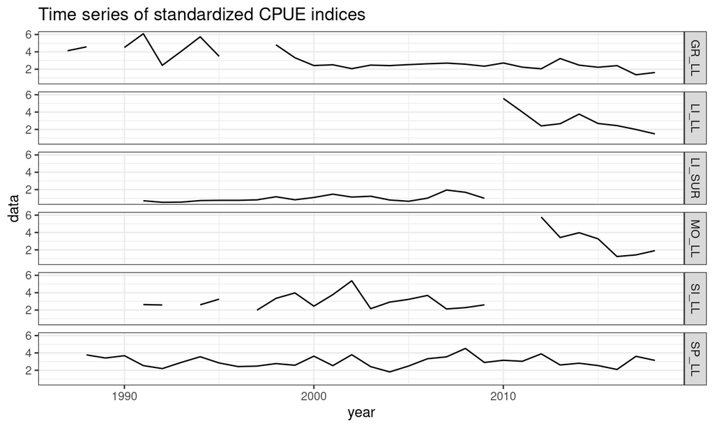

## Final runs

- Two final runs were considered:
  - one with constant M
  - one with constant M including estimated Discards
- Models specifications kept the same:
  - for \(F\), \(R\), \(\mathbf{\sigma^2}\), \(\tau^{2}_{s}\) and \(N_{1}\)
  - Q model altered according to the new CPUE index:

\[ Q : \begin{cases} \sim 1, &\quad \text{Greek longline}\\ \sim 1, &\quad \text{Spanish longline}\\ \sim s(year, k=3), &\quad \text{Moroccan longline}\\ \sim s(year, k=3), &\quad \text{Ligurian longline}\\ \sim 1, &\quad \text{Sicilian longline}\\ \sim s(year, k=9), &\quad \text{Ligurian surface longline}\\ \end{cases} \]

## final run

### assuming constant M

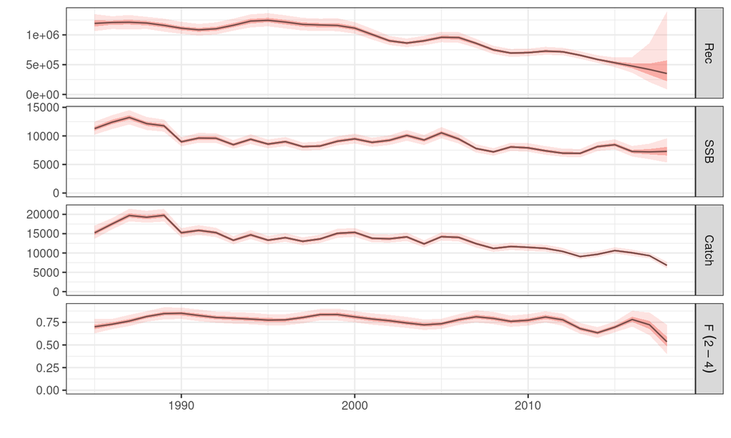

## Diagnostics

### final run assuming constant M

Standardized residuals of the catch numbers by age

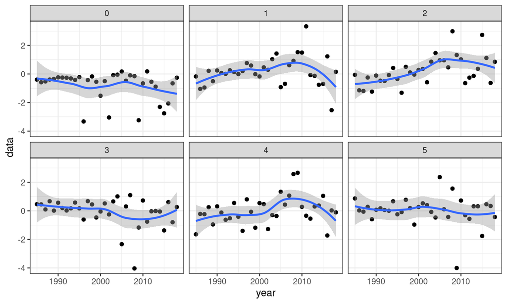

## Diagnostics

### final run assuming constant M

Standardized residuals of the CPUE series

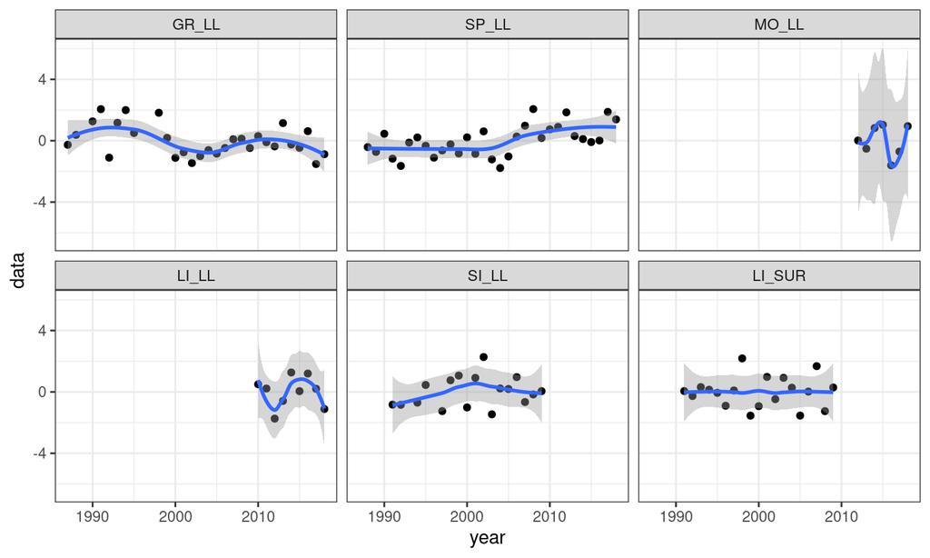

## Retrospective plot

### final run assuming constant M

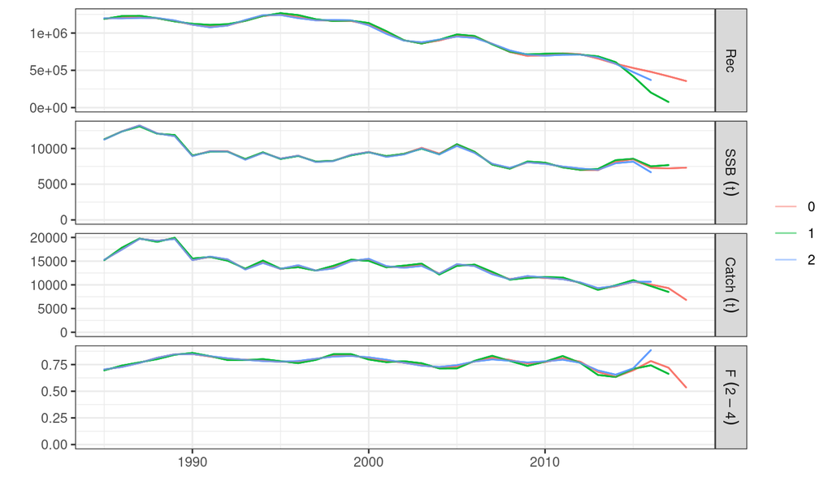

## final run

### assuming constant M discards included

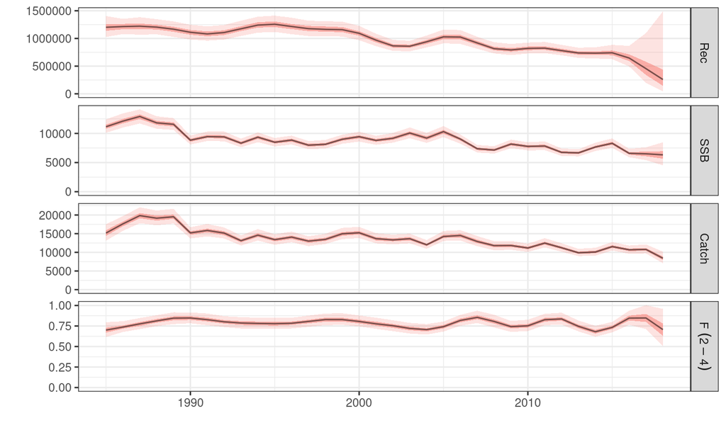

## Diagnostics

### final run assuming constant M discards included

Standardized residuals of the catch numbers by age

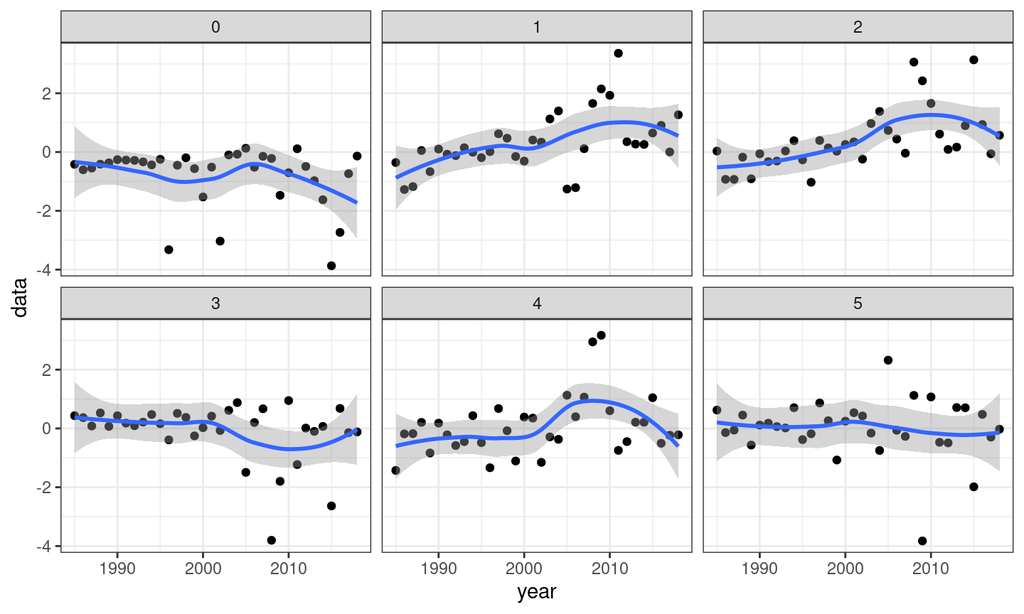

## Diagnostics

### final run assuming constant M discards included

Standardized residuals of the CPUE series

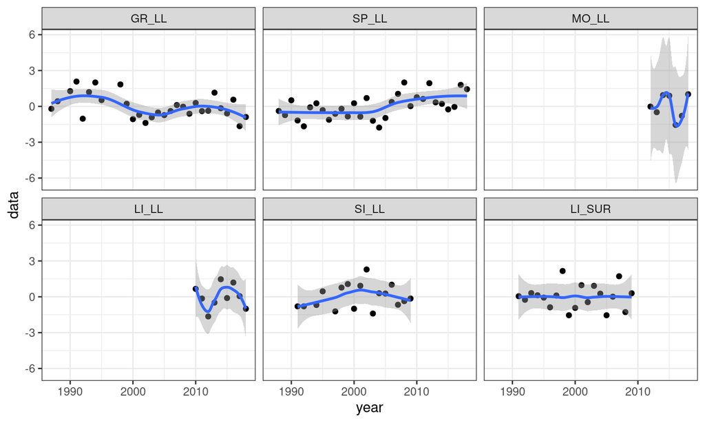

## Retrospective plot

### final run assuming constant M discards included

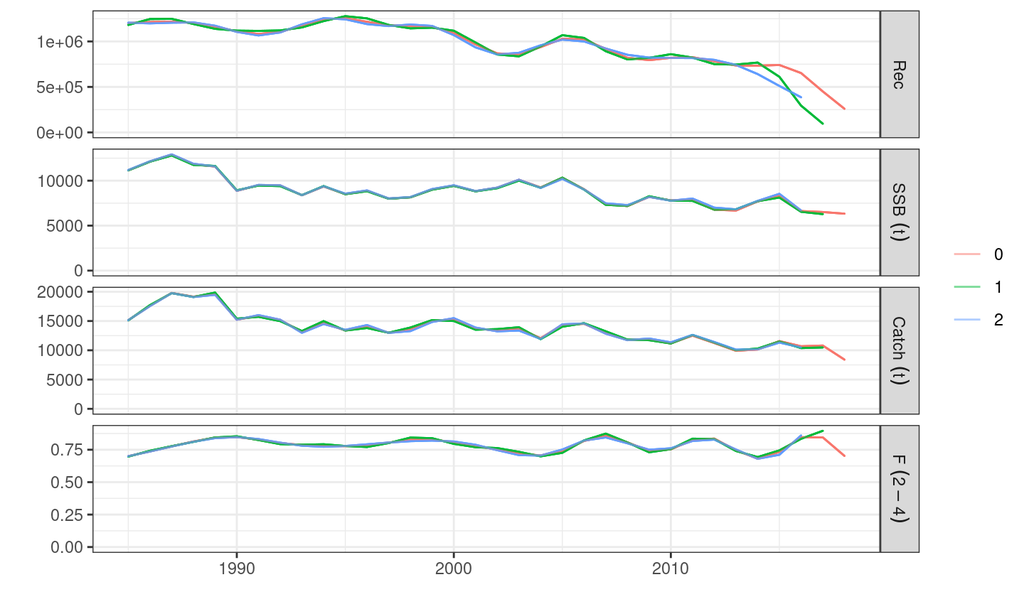

## Comparison plot

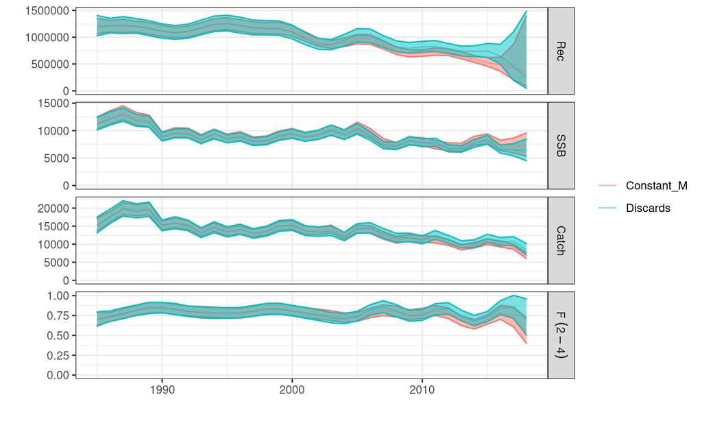

## Reference points

| value | constantM | Disc_constM |
| --- | --- | --- |
| Fmsy | 3.833524e-01 | 3.753627e-01 |
| Bmsy | 4.586190e+04 | 4.351330e+04 |
| F2018 | 5.355717e-01 | 7.024563e-01 |
| SSB | 7.312521e+03 | 6.331603e+03 |
| FFmsy | 1.397074e+00 | 1.871407e+00 |
| FF0.1 | 2.618664e+00 | 3.535289e+00 |
| BBmsy | 5.001516e-01 | 5.177004e-01 |

## MCMC

### constant M

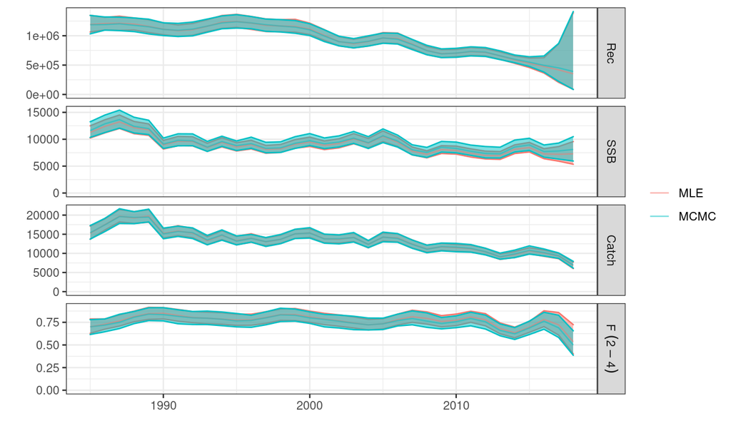

## MCMC

### constant M discards included

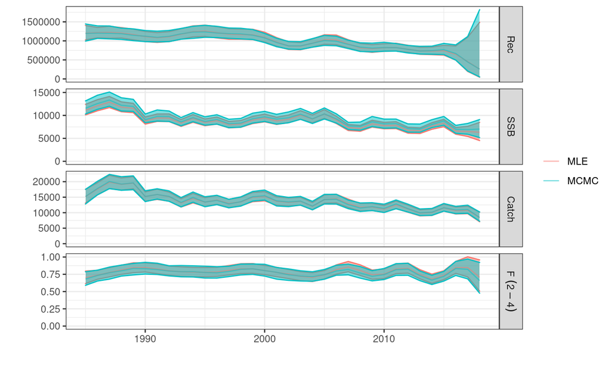